# PEOPLE-USD

## PEOPLE-USD today is +0200, 2025-11-03, 01:09:29

This crypto forecast was generated by gemini-2.0-flash API

## Daily Chart

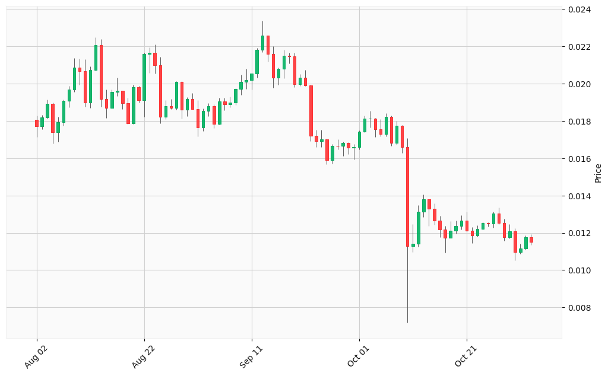

## Hourly Chart

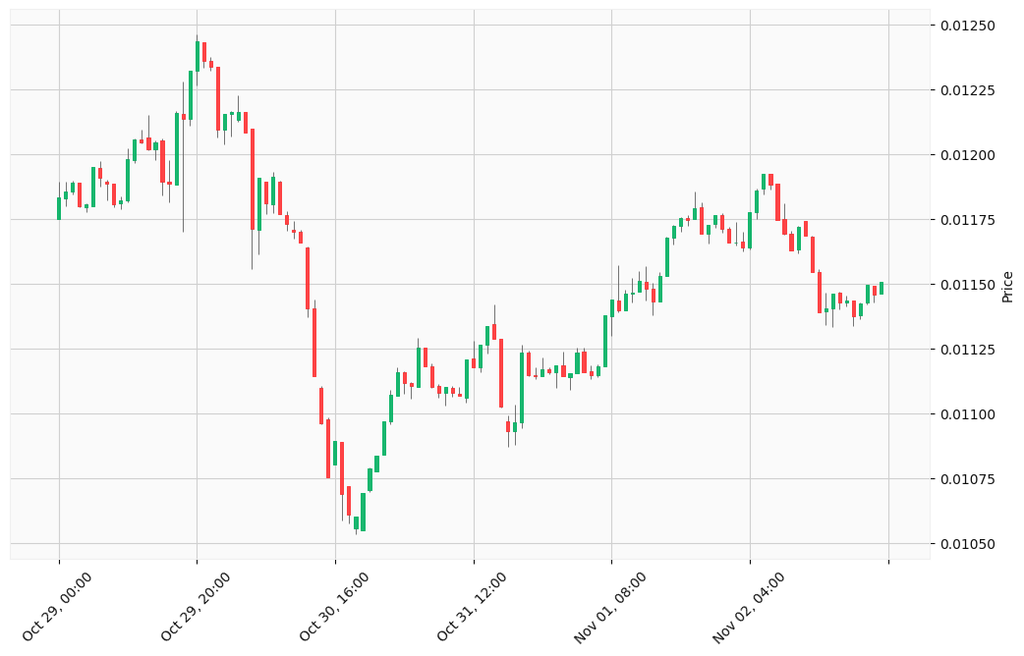

Okay, I will analyze the provided cryptocurrency data for PEOPLE-USD and generate trading signals based on the described methodology. I will use the provided OHLCV data, perform technical analysis, consider market trends, and factor in news and economic events (using the search tool for the latter).

Here’s the analysis and trading signals for PEOPLE-USD:

### 1. Market Data Collection

- **Price Data:** The provided OHLCV data is used for analysis.
- **Volume Data:** Volume data is also used in conjunction with price.
- **Market Trends:** The cryptocurrency market capitalization is around $3.6 - $3.78 Trillion. Recent news suggests institutions continue to drive crypto adoption.
- **News:** U.S. Treasury Secretary might be signaling positive sentiment towards Bitcoin.
- **Economic Indicators**: Economic indicators include GDP growth rate, interest rate, and inflation rate.

### 2. Technical Analysis

**Daily Chart Analysis (Last Three Months):**

- **Overall Trend:** Visually, the price appears to have experienced a significant drop in the middle of the observed period, followed by some recovery but remaining at a lower range than the initial prices.
- **Recent Price Action:** The most recent prices are hovering in a tight range, suggesting consolidation.

**Hourly Chart Analysis (Last Five Days):**

- **Overall Trend:** The hourly chart shows a short-term downtrend with the price decreasing from approximately 0.0118 to 0.0114.
- **Recent Price Action:** The price is currently consolidating around 0.0114 - 0.0115.

**Technical Indicators (Considerations):**

- Given the data provided, I cannot automatically calculate indicators like RSI, MACD, or Moving Averages. If I had access to a calculation library, I would compute these using the provided data.

### 3. Trend Analysis

- **Short-term:** Based on the 5-day hourly chart, a downtrend is present.
- **Long-term:** Based on the 3-month daily chart, the token has depreciated considerably.

### 4. News and Economic Analysis

- **Market Sentiment:** Recent news suggests institutions are still involved in crypto adoption.

### 5. Scenario Evaluation

- **Bearish Scenario:** Given the downtrend in both the daily and hourly charts, a continued bearish scenario is plausible. This could be further exacerbated by negative news or broader market corrections.
- **Consolidation Scenario:** The recent price consolidation suggests a period of indecision. The price may continue to trade within a narrow range until a catalyst breaks it out.
- **Bullish Scenario:** A positive catalyst, such as a major partnership announcement or positive regulatory news, could trigger a breakout from the consolidation and initiate a bullish trend.

### 6. Signal Generation

Here are potential trading signals:

**Signal 1:**

[output not shown]

**Signal 2:**

```
Signal Type: Neutral / Hold
Cryptocurrency: PEOPLE-USD
Confidence Level: Low
Take Profit Probability: 50%
Justification: Consolidation pattern observed in both short-term and long-term charts. The token needs a catalyst to break out.
Relevant Data: Price is trading in a narrow range.
Recommended Action: Hold current positions. Wait for a breakout or breakdown before making a decision. Set alerts for price movements outside the current range (0.011 to 0.013).
```

**Signal 3:**

[output not shown]

**Disclaimer:** These signals are based on the limited data provided and the current market understanding. Cryptocurrency trading is highly risky, and these signals are not financial advice. Always conduct thorough research and consult with a financial advisor before making any investment decisions.